# First Steps with Item Response Theory

Model estimation, model comparison, assumptions check in R

Dr. Ottavia M. Epifania, ottavia.epifania@unitn.it

# Getting started

## Create a new project

- New Project
- Choose the type
- Assign a directory

(This is not mandatory by it is strongly suggested)

New file $\rightarrow$ New project

[figure not shown]

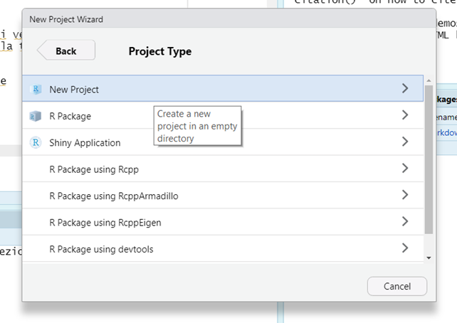

[figure not shown]

## Packages

- Installation
- Loading

```r
install.packages("lavaan")

install.packages("TAM")

install.packages("mokken")

install.packages("difR")

install.packages("tidyverse")

install.packages("ggplot2")
```

```r
library("lavaan")

library("TAM")

library("mokken")

library("difR")

library("tidyverse")

library("ggplot2")
```

## Useful code

- `IRT`
- `ICC`
- `IIF`

```r
# probability of a correct response given theta and item parameters
IRT <- function(theta, a = 1, b = 0, c = 0,e = 1) {
  y <- c + (e - c) * exp(a * (theta - b)) / (1 + exp(a * (theta - b)))
  y[is.na(y)] = 1
  return(y)
}
```

```r
# function for plotting the ICCs of the items
# returns a list with a ggplot graph (icc_graph) and a data set with the data
# used for plotting the ICC (icc_data)
irt_icc = function(model) {
  item_par = model$item
  est_theta = seq(-4,4, length.out=1000)
  item_prob = list()
  if (any(grep("guess", colnames(item_par))) == F) {
    for (i in 1:nrow(item_par)) {
      item_prob[[i]] = data.frame(theta = est_theta)
      item_prob[[i]]$it_p = IRT(item_prob[[i]]$theta,
                          b = item_par[i, "xsi.item"],
                          a = item_par[i, "B.Cat1.Dim1"])
      item_prob[[i]]$item = item_par[i, "item"]

}
  } else {
     for (i in 1:nrow(item_par)) {
      item_prob[[i]] = data.frame(theta = est_theta)
      item_prob[[i]]$it_p = IRT(item_prob[[i]]$theta,
                          b = item_par[i, "AXsi_.Cat1"],
                          a = item_par[i, "B.Cat1.Dim1"],
                          c = item_par[i, "guess"])
      item_prob[[i]]$item = item_par[i, "item"]

}
  }
  p = do.call("rbind", item_prob)
  gp = ggplot(p,
       aes(x = theta, y = it_p, group = item, col =
             item)) + geom_line(lwd = 1)
  object = list(icc_data = p,
              icc_graph = gp)

return(object)
}
```

```r
irt_iif = function(model) {
  est_theta = IRT.factor.scores(model,
                              type = "EAP")$EAP
ii = IRT.informationCurves(model, theta = est_theta)

test_info = data.frame(theta = est_theta,
               info = ii$test_info_curve,
               se = ii$se_curve)

iif_info = list()
for(i in 1:nrow(ii$info_curves_item)) {
    iif_info[[i]] = data.frame(theta = est_theta)
    iif_info[[i]]$ii_item = ii$info_curves_item[i, ]
    iif_info[[i]]$item = dimnames(ii$info_curves_item)[[1]][i]
}

dat_info = do.call("rbind", iif_info)

info_tot = list(test_info = test_info,
                item_info = dat_info)

return(info_tot)
}
```

## Import data

Download the file `dataClass.csv` from this [shared folder](https://drive.google.com/drive/folders/1EF4cN4yiB3Fft_y2Mh4r0Mclxc6bTRdf?usp=sharing).

Store the downloaded file in the `data` sub folder of your newly created project and run this code:

```r
data = read.csv("data/dataClass.csv", header = T, sep = ",")
```

## Look at the data!

- The items
- The respondents

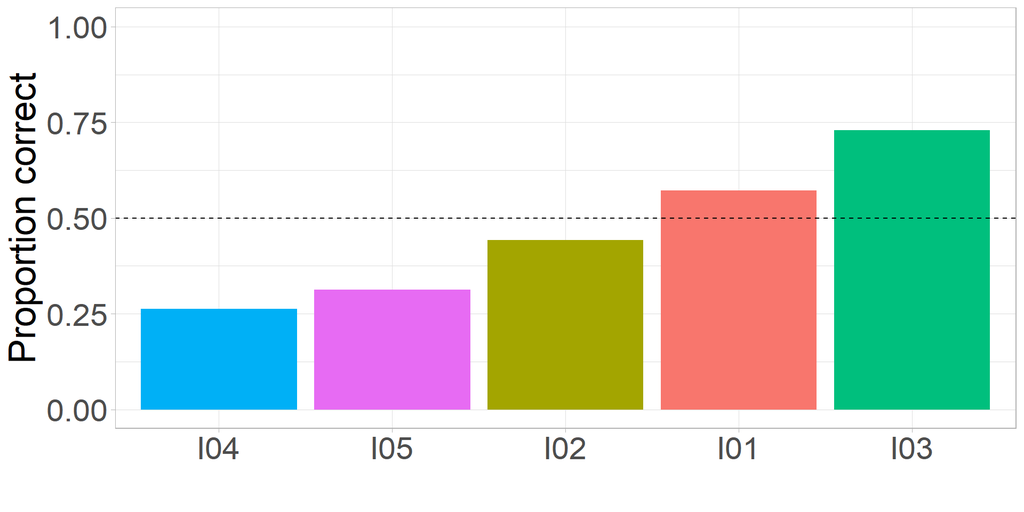

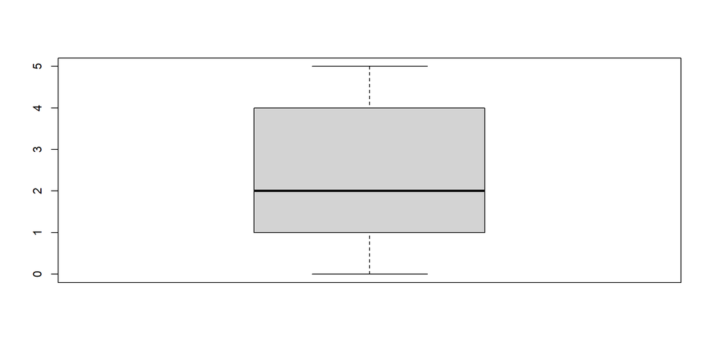

```r
vis_data = data
vis_data$id = paste0("s", 1:nrow(data))

vis_data = vis_data[, c(ncol(vis_data), 1:ncol(data))]
vis_data = pivot_longer(vis_data, names_to = "item", cols = -1)

prop_data = vis_data %>%
  group_by(item) %>%
  summarise(proportion = mean(value))

ggplot(prop_data,
       aes(x = reorder(item, proportion), y=proportion,
           fill = item)) + geom_bar(stat = "identity") +
  theme(axis.text = element_text(angle = 90)) + geom_hline(aes(yintercept=.50), linetype = 2) + ylab("Proportion correct") + xlab("") +
  theme_light() + ylim(0, 1) +
  theme(
    legend.position = "none",
    axis.title = element_text(size = 26),
    axis.text = element_text(size = 22))
```

```r
sbj_data = data
sbj_data$id = paste0("s", 1:nrow(data))
sbj_data = sbj_data[, c(ncol(sbj_data), 1:ncol(data))]

sbj_data$sum = rowSums(sbj_data[,-1])

boxplot(sbj_data$sum)
```

# Assumptions

## IRT assumptions

There are three main assumptions:

1. Monotonicity
2. Unidimensionality
3. Local independence

If these assumptions are violated, the models can still be fitted but their interpretation is meaningless

## Monotonicity

The probability of responding correctly increases as the the level of the latent trait increases

Monotonicitiy is evaluated at the item level with the $H$ coefficient by Mokken (1971):

> $H \leq .30$ $\rightarrow$ The item is not monotone, should be discarded

> $.30 < H \leq .50$ $\rightarrow$ The item is essentially monotone, this is fine

> $H > .50$ $\rightarrow$ The item is monotone, this is optimal

**If violated**

Issues on the reliability and validity of the measure

## Monotonicity in `R`

Monotonicity is checked with the [`mokken`](https://cran.r-project.org/web/packages/mokken/mokken.pdf) package in `R`:

[output not shown]

```r
library(mokken)
mono_check = check.monotonicity(data)
summary(mono_check)
```

## Unidimensionality

Unidimensionality $\rightarrow$ There’s only one latent trait that is responsible for the observed responses

**How**

**Confirmatory Factor Analysis models** (CFA)

**If violated**

The parameter estimates might be distorted and/or could not be interpreted

Even if the estimates could be interpreted, they would have no meaning because the model has no meaning

There are IRT models that are designed for dealing with multidimensional latent traits

## Unidimensionality - CFA

CFA models that force a one-factor solution to the data:

- If the one-factor model has a good fit to the data $\rightarrow$ it is reasonable to assume the unidimensionality
- If the one-factor model does not have a good fit to the data $\rightarrow$ unidimensionality is not supported, it is best to first understand the latent structure of the data

**CFA fit indexes**:

> Comparative Fit Index (CFI) $\geq .90$

> Standardized Root Mean Square Residual (SRMSR) $\leq.08$

> Root Mean Square Error of Approximation (RMSEA) $\leq. 08$

## Unidimensionality - Practice

The CFA model is fitted with the [`lavaan`](https://cran.r-project.org/web/packages/lavaan/lavaan.pdf) package:

- Define the model
- Fit the model

[output not shown]

```r
item_lab = paste(colnames(data), collapse = " + ")
form = paste("latent =~", item_lab)
```

[output not shown]

[output cut: 27 more lines]

[output not shown]

```r
model = cfa(form, data = data,  ordered = colnames(data), std.lv = T)
summary(model, fit.measures = T)
```

## Local independence

The probability of observing a pattern of responses to a set of items is equal to the product of the probabilities associated with each response to each item:

$$P(x_{p1}, x_{p2}, \ldots, x_{pi}) = P(x_{p1})P(x_{p2}) \ldots P(x_{pi})$$

The correlation between the observed responses “disappears” once the effect of the latent variable has been taken into account

**If violated**

There is something else other than the latent variable, issues for the validity and reliability of the measure

## Local indepedence - How

It is based on the correlations between the residuals of the IRT model $\rightarrow$ the distance between the observed data and the data expected according to the model

Under the assumption of local independence, the residuals are expected not to be correlated

The usual statistics for interpreting the correlation between the residuals is the $Q3$ statistics (Yen, 1984)

This statistics is computed between the residuls of every pair of items

> $Q3 > .20$ suggests an high correlation between the residuals of two items, indicating local dependence $\rightarrow$ one of the item should be deleted

# Model estimation

## Model estimation in R

The [`TAM`](https://cran.r-project.org/web/packages/TAM/TAM.pdf) package allows for the estimation of IRT models in `R`

Multiple-choice items, coded as 0 (incorrect response) and 1 (correct response):

```r
m1pl = tam.mml(data, verbose = F)

m2pl = tam.mml.2pl(data, irtmodel = "2PL", verbose = F)

m3pl = tam.mml.3pl(data, est.guess = colnames(data), verbose = F)
```

## Model comparison

```r
IRT.compareModels(m1pl, m2pl, m3pl)
```

```
$IC
  Model   loglike Deviance Npars Nobs      AIC      BIC     AIC3     AICc
1  m1pl -2762.350 5524.699     6 1000 5536.699 5566.146 5542.699 5536.784
2  m2pl -2721.966 5443.933    10 1000 5463.933 5513.010 5473.933 5464.155
3  m3pl -2720.248 5440.496    16 1000 5472.496 5551.020 5488.496 5473.050
      CAIC       GHP
1 5572.146 0.5536699
2 5523.010 0.5463933
3 5567.020 0.5472496

$LRtest
  Model1 Model2      Chi2 df            p
1   m1pl   m2pl 80.766596  4 1.110223e-16
2   m1pl   m3pl 84.203069 10 7.494005e-14
3   m2pl   m3pl  3.436473  6 7.524016e-01

attr(,"class")
[1] "IRT.compareModels"
```

## 2PL - Model fit

```r
f.m2pl = tam.modelfit(m2pl, progress = F)
f.m2pl$statlist
f.m2pl$modelfit.test
```

- `statlist`
- `modelfit.test`

```
  X100.MADCOV       SRMR      SRMSR    MADaQ3 pmaxX2
1   0.3492573 0.01591987 0.01713347 0.0714379      1
```

```r
fit_m2pl$modelfit.test
```

```
      maxX2 Npairs p.holm
1 0.9536516     10      1
```

## Local dependence

- Summary
- LD – Items

```r
fit_m2pl$Q3_summary
```

```
  type             M        SD        min         max     SGDDM    wSGDDM
1   Q3 -1.624306e-01 0.0916599 -0.3497230 -0.05557536 0.1624306 0.1624306
2  aQ3  1.030287e-17 0.0916599 -0.1872924  0.10685520 0.0714379 0.0714379
```

```r
local_dep = function(model, cut = NULL) {
  fit_model = tam.modelfit(model, progress = FALSE)
  temp_local = fit_model$Q3.matr
  index = which( upper.tri(temp_local,diag=F) , arr.ind = TRUE )
  local = data.frame( col = dimnames(temp_local)[[2]][index[,2]] ,
                      row = dimnames(temp_local)[[1]][index[,1]] ,
                      val = temp_local[ index ] )

  if (is.null(cut) == TRUE) {
      summary_local = local
  } else {
     summary_local = local[local$val > cut, ]
  }
  return(summary_local)
}

local_dep(m2pl)
```

```
   col row         val
1  I02 I01 -0.18357094
2  I03 I01 -0.11032327
3  I03 I02 -0.16445409
4  I04 I01 -0.07012394
5  I04 I02 -0.30916375
6  I04 I03 -0.05557536
7  I05 I01 -0.14497861
8  I05 I02 -0.34972296
9  I05 I03 -0.12466460
10 I05 I04 -0.11172807
```

## 2PL - Item parameters

- Model summary
- Item Characteristics Curves (ICC)

```r
summary(m2pl)
```

```
------------------------------------------------------------
TAM 4.2-21 (2024-02-19 18:52:08)
R version 4.4.2 (2024-10-31 ucrt) x86_64, mingw32 | nodename=EPIFANIA | login=Ottavia

Date of Analysis: 2025-02-05 18:00:28.496572
Time difference of 0.09988594 secs
Computation time: 0.09988594

Multidimensional Item Response Model in TAM

IRT Model: 2PL
Call:
tam.mml.2pl(resp = data, irtmodel = "2PL", verbose = F)

------------------------------------------------------------
Number of iterations = 72
Numeric integration with 21 integration points

Deviance = 5443.93
Log likelihood = -2721.97
Number of persons = 1000
Number of persons used = 1000
Number of items = 5
Number of estimated parameters = 10
    Item threshold parameters = 5
    Item slope parameters = 5
    Regression parameters = 0
    Variance/covariance parameters = 0

AIC = 5464  | penalty=20    | AIC=-2*LL + 2*p
AIC3 = 5474  | penalty=30    | AIC3=-2*LL + 3*p
BIC = 5513  | penalty=69.08    | BIC=-2*LL + log(n)*p
aBIC = 5481  | penalty=37.28    | aBIC=-2*LL + log((n-2)/24)*p  (adjusted BIC)
CAIC = 5523  | penalty=79.08    | CAIC=-2*LL + [log(n)+1]*p  (consistent AIC)
AICc = 5464  | penalty=20.22    | AICc=-2*LL + 2*p + 2*p*(p+1)/(n-p-1)  (bias corrected AIC)
GHP = 0.54639     | GHP=( -LL + p ) / (#Persons * #Items)  (Gilula-Haberman log penalty)

------------------------------------------------------------
EAP Reliability
[1] 0.72
```

[output cut: 13 more lines]

```
Item Parameters -A*Xsi
  item    N     M xsi.item AXsi_.Cat1 B.Cat1.Dim1
1  I01 1000 0.572   -0.381     -0.381       1.268
2  I02 1000 0.443    0.722      0.722       4.859
3  I03 1000 0.729   -1.323     -1.323       1.358
4  I04 1000 0.263    1.583      1.583       1.799
5  I05 1000 0.313    1.432      1.432       2.353

Item Parameters in IRT parameterization
  item alpha   beta
1  I01 1.268 -0.300
2  I02 4.859  0.149
3  I03 1.358 -0.974
4  I04 1.799  0.880
5  I05 2.353  0.609
```

[figure not shown]

```r
icc_2pl = irt_icc(m2pl)$icc_data
item = m2pl$item_irt
icc_2pl = merge(icc_2pl, item)
icc_2pl$item_label = paste0(icc_2pl$item, ", b =",
                            round(icc_2pl$beta, 2), ", a = ", round(icc_2pl$alpha, 2))

ggplot(icc_2pl,
       aes(x = theta, y = it_p, group = item_label, color = item_label)) +
  geom_line(linewidth = 1.2) + theme_classic() +
    ylab(expression(paste("P(", x[ip], " = 1|", theta, ", ", b[i], ", ", a[i], ")"))) + xlab(expression(theta)) +
  theme(legend.position = c(.15, .80),
        legend.title = element_blank(),
        legend.text = element_text(size = 18),
        axis.title = element_text(size = 26)) +
  geom_hline(yintercept = .50, linetype = 2)
```

# Information Functions

## Information Functions

- IIF
- TIF
- SE

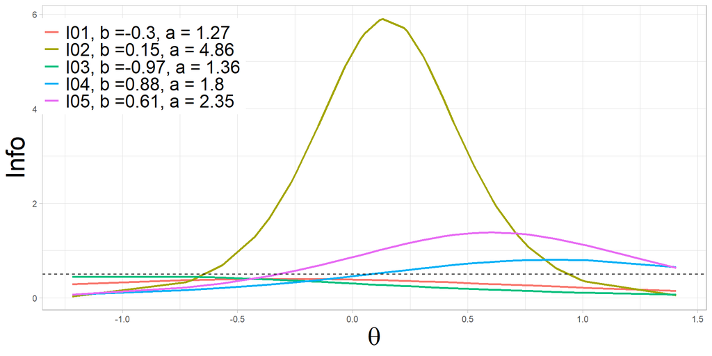

[figure not shown]

```r
label_item = icc_2pl[, c("item", "item_label")]
label_item = label_item %>% distinct()

info2pl = irt_iif(m2pl)
item_info = info2pl$item_info
item_info = merge(item_info, label_item)

ggplot(item_info,
       aes(x = theta, y = ii_item, group = item_label, color = item_label)) + geom_line(lwd = 1) + theme_light()+ xlab(expression(theta)) + ylab("Info")+
  theme(legend.position = c(.15, .80),
        legend.title = element_blank(),
        legend.text = element_text(size = 18),
        axis.title = element_text(size = 26)) +
  geom_hline(yintercept = .50, linetype = 2)
```

[figure not shown]

```r
ggplot(info2pl$test_info,
       aes(x = theta, y = info)) + geom_line(lwd = 2) + theme_light() +
  xlab(expression(theta)) + ylab("Info") +
  theme(axis.text = element_text(size = 18),
        axis.title = element_text(size = 26))
```

```r
ggplot(info2pl$test_info,
       aes(x = theta, y = se, col = "SE")) + geom_line(lwd = 2) + + theme_light() +
  xlab(expression(theta)) + ylab("Info") +
  theme(legend.position = "none",
        axis.text = element_text(size = 18),
        axis.title = element_text(size = 26))
```

[output not shown]

## Your turn!

Download the data set “dataES_stima.csv” from the [shared folder](https://drive.google.com/drive/folders/1EF4cN4yiB3Fft_y2Mh4r0Mclxc6bTRdf?usp=sharing).

Store the downloaded file in the `data` sub folder:

- Import the dataset
- Look at the data! (Both items and respondents)
- Check the monotonicity and unidimensionality assumptions
- Fit of the IRT models & choose the best model
- Check the local independence assumption
- Obtain the ICCs, IIFs, and TIF of the test